# Audition pour le poste MCF n°261198

Section 60 - INSA Lyon (GM) - LaMCoS (MECALIPS)  
Biomécanique, Méthodes numériques, Mécanique des solides et structures, Éléments finis

Flavien Loiseau

flavien.loiseau@ensta.fr

May 26, 2026

## Parcours

2011–2014

**BAC Technologique STI2D** (spécialité ITEC)

2014–2016

**CPGE Techniques et Sciences Industrielles**

2016–2020

**ENS Paris-Saclay**

- L3 pluridisciplinaire (GM, GC, GE)
- M1 Mécanique des Matériaux et des Structures
- M2 Formation à l’Enseignement Supérieure en Mécanique
- M2 Mécanique des mAtériaux pour l’inGénierie et l’Intégrité des Structures

2020–2023

**Thèse au Laboratoire de Mécanique Paris-Saclay**

Encadrée par Rodrigue Desmorat et Cécile Oliver-Leblond

2024–…

**Post-doctorat à l’IMSIA** (ENSTA)

Encadré par Véronique Lazarus

# Enseignement

1 Expériences en enseignement  
2 Projet d’intégration  
3 Mise en situation

## Activités en enseignement

Avant 2020

**Divers**

Aide aux devoirs (Lycée)  
Préparation examens et TP (IUT Cachan, GMP)

2020–2023  
3 $\times$ 64h

**Mission d’enseignement**  
ENS Paris-Saclay Génie Civil (L3, M1)

Méthodes Numériques, Propagation d’ondes, Mécanique des Fluides, Matlab  
**Évolution formation :**  
Sujet de TD en Méthodes Numériques

2024–2026  
42h+51h

**Vacations**  
ENSTA Mécanique (1A, 2A)

MMC solide élastique, Comportements non-linéaires, Fatigue, Rupture, Projet Matlab  
**Évolution formation :**  
Supports numériques de TP en Rupture  
Code Python utilisant FEniCSx + Docker (pérénisation)

[figure not shown]

Contribution : Sujet de méthodes numérique de M1.

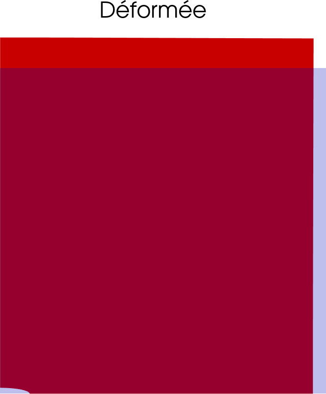

Contribution : Supports numériques de TP de Mécanique de la rupture.

## Évolution des formations

Illustrer les slides avec le TP (mousse) et TP MN ou Matlab Lorenz

Mettre une slide à part pour illuster l’évolution des formations ???

## Intégration dans les formations

#### Adéquation au profil

**Mécanique des milieux continus**

- Formation + Propagation d’ondes + MMC Solides Élastiques, Mécanique des Fluides

**Méthodes numériques appliquées à la mécanique**

- Formation, Enseignements : TD/TP Méthodes numériques, TP Numériques Mécanique de la rupture, TP Numériques Méca Flu, projet Matlab

**Calcul de structures par éléments finis** en Cours/TD/TP

**Elle pourra également s’investir dans les enseignements**

- Conception
  - Formation (de la STI2D au M2 FESup)
- Biomécanique appliquée à la santé.
  - Mise à niveau nécessaire (au travers de la recherche?)

[figure not shown]

#### Compétences techniques

**Logiciels métiers** : Un peu de abaqus

## Implications pédagogiques

#### Pédagogie par projet

C’est une manière d’enseigner dont j’ai beaucoup profité et dans laquelle j’ai bcp appris.

Connaissances transvervales -> STI2D + L3 pluridisciplinaire + FESup

Lien avec l’industrie, prêt à s’investir pleinement.

#### Évolution des enseignements

**Défis pédagogiques en MMC et Méthodes Numériques**

Notions abstraites  
Ex : CAO, normes cotations, procédés, etc.

Calculatoire  
Ex : Considérer la fabrication dès la conception.

**Approches envisagées**  
Illustration interactifs  
Animations / Ressources interactives.  
Ex : Tenseur des contraintes.

Lien cours vs mise en pratique (MN) ???  
Mise en pratique rapide (TP, projet).  
Proposition de ressources méthodologiques.

#### Autres implications

- Intégration enjeux sociétaux  
  *Aspects environnementaux*  
  *Intelligence artificielle*
- Enseignements en anglais (niveau C1)
- Supports pédagogiques  
  *Interactifs (jupyter, marimo), Accessibles (Quarto)*
- À terme, responsabilités péda ou plateforme

## Mise en situation pédagogique

Cycle Ingénieur 1ère année, Semestre 2 Mécanique des Solides Déformables

*Mise en contexte pour le dimensionnement d’une structure treillis*

## Structures en treillis

Qu’est-ce qu’une structure treillis ?

**Définition : Structure en treillis**

- Structure composé d’élements
- Apparition avec la révolution industrielle
- Illustration de vieille structures
- Intérêts : légèreté, tenue mécanique, économie de matière, facilité de montage, pièces standards

## Où est-ce qu’on les trouve maintenant ?

- Ouvrage d’art (tours, points, bâtiments, …)
- Automobile (chassis/arceau) -> Formula Student -> Équipe INSA Lyon
- Aéronautique (membrures ailes, fuselage)
- Énergie : Pylônes
- Milieux architecturés (DEAP?)
- Concert / Tentes

## Qu’est-ce que dimensionner une structure treillis ?

- Choix de matériaux, longueurs, sections, etc.
- En fonction des sollications (poutre: traction/compression/flexion/etc, monotone/cyclique), des contraintes (cahier des charges)

## Example d’un problème de dimensionnement d’une structure treillis avec les enjeux sociétaux associés (cet example servira de fil rouge).

- Cette exemple pourra être revu dans le cours (comme example ou traiter en TD)

## Comment est-ce qu’on les modélise ?

- On pourrait faire du full 3D comme on a vu dans le cours
- En pratique, on va pouvoir supposer que les barres sont des poutres, ce qui va ÉNORMÉMENT simplifier les calculs.

# Recherche

1 Expériences en recherche  
2 Projet d’intégration

## Thèse au LMPS

**2020–2023**

[figure not shown]

**Formulation de l’endommagement anisotrope des matériaux et stuctures quasi-fragiles basée sur la simulation discrète de la fissuration**  
R. Desmorat, C. Oliver-Leblond  
*2 articles, 2 conférences internationales, 1 conférence nationale, 2 GdR.*

Model damage in micro-cracking material $\boldsymbol{\sigma} = \tilde{\mathbf{E}}(\mathbf{D}) : \boldsymbol{\varepsilon}$ from discrete simulations

#### 1. Discrete simulations

21 loads  
36 $\mu$-structures $\to$ 76k steps

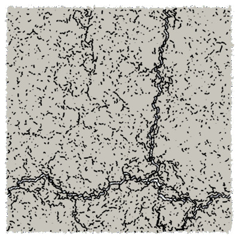

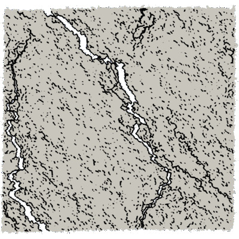

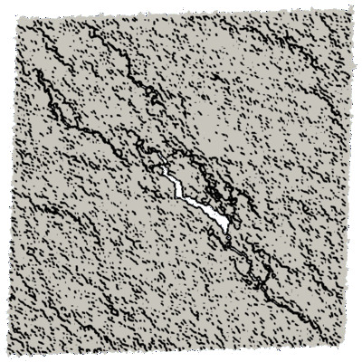

#### 2. Effective elasticity tensors

[figure not shown]

Analysis of symmetry classes

#### 3. Modelling

1. Damage definition
   $$\mathbf{D} = \mathbf{1} - \frac{1}{\kappa_0} \mathrm{tr}_{12} (\mathbf{E})$$
2. Harmonic decomposition

[figure not shown]

Loiseau et al. (2023) and Védrine et al. (2025) Dataset: https://doi.org/10.57745/LYHM4W

## Postdoc at IMSIA - Overview

**2024–Now**

[figure not shown]

Theoretical and numerical study of crack propagation  
in heterogenous and/or anisotropic materials  
V. Lazarus  
*2(+3) articles, 4(+2) international conferences, 3 national conferences.*

**Open-source codes for 2D crack propagation**

[**floiseau/gcrack**](https://github.com/floiseau/gcrack) (LEFM<sup>1</sup>)

[**floiseau/fragma**](https://github.com/floiseau/fragma) (phase-field)

**Main features**

- Load control  
  (path-following)
- Fracture anisotropy
- Heterogeneities (fragma)
- Fatigue (gcrack)

[figure not shown]

Fracture of a 3D-printed polycarbonate specimen. Experiments by Zhai et al. (2025) at IMSIA.

[^1]: LEFM = Linear Elastic Fracture Mechanics

## Postdoc at IMSIA - Numerical aspects

Develop robust numerical tools for crack propagation in anisotropic materials

#### Load control

**Path-following & fracture**  
Loiseau & Lazarus (2026)

Force load + Fracture = Instable  
$\rightarrow$ Novel path-following method

[figure not shown]

#### Limiting numerical bias in phase-field simulations of fracture

**Initial cracks**

Loiseau & Lazarus (2025)

$\rightarrow$ Unbiased initial crack  
in phase-field fracture

[figure not shown]

**Mesh-induced bias**

E. Zembra & H. Henry (PMC)

$\rightarrow$ Quantify mesh bias  
in crack path pred

[figure not shown]

## Postdoc at IMSIA - Applications

Predict crack propagation in real systems

#### Collaborations with experimenters

**Fracture in rotating structures**  
G. Yakir & P. Reis (EPFL)

- Determination of the crack propagation threshold

[figure not shown]

**Fracture in 3D-printed structures**  
IMSIA

Duplex steel (D. Roucou & N. Habib)  
Polycarbonate (X. Zhai)  
Repaired steel structures (L. Kiakouama)  
Specimen design (K. Paquet)

**Others** Mixed mode fracture in PMMA (D. Roucou)

#### Other collaborations

**Sparse analytical regressions**  
Safran Aircraft Engines (discussion for applications)  
Applications : Fracture in rotating structures  
Modelling of 3D-printed Duplex steel  
Revisiting fracture mechanics handbooks  
Finding a sparse analytical expression from data  
Simplicity vs accuracy tradeoff

**Optimization of dissipation during crack propagation**  
J. Triclot (LMA)

- Simulation of crack propagation  
  with load control

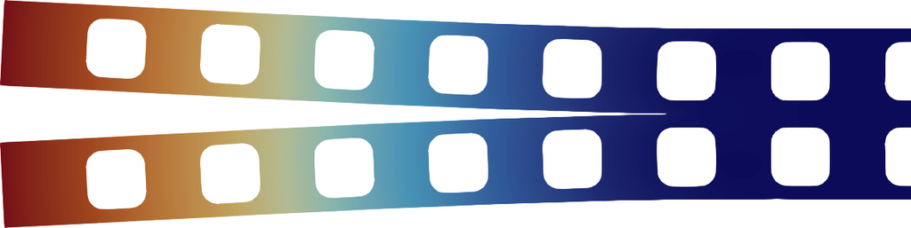

## Encadrements

#### Effect of crack distribution on the elasticity tensor

*2022 - A. Marlot - M1 ENS Paris-Saclay*

[figure not shown]

#### Study of size effect in discrete simulation

*2023 - L. Védrine - M2 ENS Paris-Saclay*

[figure not shown]

#### Phase-field simulations of anisotropic fracture

*2024 - A. Ecotiere - 2A ENSTA*

#### Crack propagation in mixed mode I+II in CCT specimen

*2025 - Y. M. V. Epongue Djeugoue - 2A ENSTA* *Experiments by D. Roucou at IMSIA.*

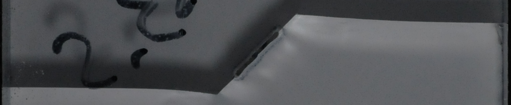

[video not shown]

## Intégration en recherche

*Équipe MECALIPS du LaMCoS*

**Objectif global**  
Modéliser et simuler les mécanismes physiopathologiques de maladies chroniques

[figure not shown]

#### Verrous et propositions

**Comment modéliser les tissus biologiques (et des implants) ?**  
Développer des modèles de comportements dédiés dans un cadre générique  
Cadre de modélisation macroscopique unifié basé sur la thermodynamique  
Modéles continus (classique ou *data-driven* interprétable) ou discrets à plusieurs échelles  
Couplages bio-chimio-mécaniques (dégradation, croissance, remodellage, etc.), anisotropie, hétérogénéités

**Comment simuler les maladies étudiées et leur développement de manière robuste et personalisable ?**  
Développer des outils numériques s’appuyant sur le cadre de modélisation générique  
Solveurs non-linéaires/minimisation adaptés au cadre de modélisation  
Mise en données à partir des données médicales disponibles  
Vers des outils adaptés au milieu clinique (, etc.)

#### En collaboration

Conceptualisation d’expériences

Vers des méthodes numériques efficaces  
Solveurs optimisés, réduction de modèle

## Intégration dans l’équipe MECALIPS

#### NOTE : Pas d’experience en bio-mécanique

Mais ce sont des thématiques auxquelles je me suis intéressé (travaux de recherche à l’IMSIA, conférences)

Thématiques qui m’attire en terme d’enjeux associés et en terme de science (les approches utilisés pour les matériaux industriels ne sont pas forcément adaptés)

- Composer avec les thématiques de l’équipe !

#### Idée globale

Développer des cadres théoriques et outils numériques adaptables à différentes problématiques

- Cadre de modélisation générique :
  - méthode variationnel incrémentale -> MSG, potentiellement des extensions si nécessaire de développer des modèles non-standards
  - aussi possible de contribuer à des approches multi-échelles -> modèles discrets
  - Applicaiton : modélisation des tissus biologiques, couplages multi-physiques,
  - ce cadre sert pour la recherche, ensuite on peut créer des outils spécifiques optimisés pour les praticiens.
- Outils numériques adaptées à ce cadre
  - calibration
  - réduction de modèle (utilisant le cadre générique proposé)

#### Verrous scientifiques et propositions

**Comment modéliser le comportement des tissus biologiques (et des implants) ?**  
Développer des modèles de comportements dédiés  
Phénomènes : endommagement, chimio-mécanique, cicatrisation, remodelage, etc.  
Propriétés : anisotropie, hétérogénéités, etc.  
Prise en compte des phénomènes complexes (endommagement, couplage chimio-mécanique, remodelage, etc) avec des propriétés complexes (anisotropie, Hétérogénéités).  
Approches : classique, *data-driven* (interpretable, contrainte par la physique).

**Comment simuler les maladies étudiées de manière robuste et adaptable ?**  
Développer un cadre numérique générique  
Établir un cadre unifié pour les comportements -> généralisation des contributions suivantes  
Calibration des modèles à partir des données médicales disponibles  
Rendre les outils numériques utilisables par les praticiens (modèles réduits ou simplifiés)

[figure not shown]

Palier du moteur CFM56.

## Cadre global

Approche variationnelle incrémentale (avec traitement des interfaces)

$$\mathcal{P}(\boldsymbol{u}, ...) =
\mathcal{P}_{\Omega_1}(\boldsymbol{u}, ...) +
\mathcal{P}_{\Omega_2}(\boldsymbol{u}, ...) +
\mathcal{P}_{\partial \Omega_{1+2}}(\boldsymbol{u}, ...)$$

#### Simulations patient-spécifique

Gestion du comportement par définition de potentiels (classique ou IA)

Solver non-linéaire/minisation -> générique

Utilisation outils d’auto-diff pour simplifier la calibration.

## Intégration dans l’axe bucco-dentaire

Prédire le risque de lésion dentaire / rupture d’implant

#### Répresentation de base

[figure not shown]

#### Contributions

1. Simulation du contact dentaire  
   Contact approché : Third Medium Contact (Wriggers et al., 2013).  
   Vers l’adaptation : morphologie, implant, etc.
2. Modélisation du comportement des tissus dentaires et implants  
   Anisotropie, endommagement (méca/chimique), usure, etc.  
   Approche multi-échelle basée sur des modèles discrets

#### Example d’application

- Initiation/Propagation d’une fissure dentaire (monotone/cyclique)  
  Prise en compte de défauts morphologiques / malocclusion  
  Modélisation de l’érosion dentaire

#### Extensions

- Cicatrisation et remodellage osseux autour d’un implant
- Vers une modélisation complète de la machoire, puis du crâne

## Intégration dans l’axe articulaire

Prédure l’usure d’une prothèse de hanche et son influence sur son environnement

#### Prothèse de hanche

[figure not shown]

Illustration simplifiée d’une prothèse de hanche

#### Contributions

1. Modélisation et simulation macroscropique de l’usure des prothèses  
   Chimio-mécanique (transport phospholipides $\rightarrow$ lubrification)  
   Emission de particules d’usure (*e.g.*, loi de Archard + $r$-adaptation)  
   Endommagement/Rutpure
2. Transport (et réactions ?) des particules $\rightarrow$ interface et tissus proches

#### Example d’application

Validation d’implants sur mesure  
Évaluation de la tolérance aux défauts de l’implant (fissures)  
Prévision des risques liés à l’usure

## Projet spécifique : En pratique

#### Implémentation numérique

**FEniCSx** avec solveurs non-linéaire (PETSc/TAO)  
$\rightarrow$ Si instabilités numériques : régularisation ou gradient de Sobolev.

[figure not shown]

#### Démarche

[figure not shown]

#### Intérêt

Cadre numérique générique pour traiter des problèmes de contacts sous-sollicitations extrêmes.

#### Limites

Glissement/roulement $\implies$ Distorsion du maillage  
$\rightarrow$ $r$-adaptation du maillage ?

#### Autre application

Simulation de procédés de fabrication

## Synthèse

#### Intégration en enseignement

- Formation à l’enseignement
- Expériences (ENS Paris-Saclay, ENSTA)
- Intérêt pour la pédagogie active

🎓 **FIMI**  
🎓 **Génie Mécanique**

#### Intégration en recherche

Modèles de comportement et outils numériques prédictifs  
pour la simulation du contact entre solides déformables  
sous sollicitations extrêmes.

**Engagements**  
Sciences ouvertes  
Animation scientifique

Merci pour votre attention !

[figure not shown]

Presentation at  
floiseau.github.io

## References

Loiseau, F., & Lazarus, V. (2025). How to introduce an initial crack in phase field simulations to accurately predict the linear elastic fracture propagation threshold? *Journal of Theoretical, Computational and Applied Mechanics*. https://doi.org/10.46298/jtcam.15198

Loiseau, F., & Lazarus, V. (2026). Path-following methods for phase-field simulation of quasi-static crack propagation. *International Journal of Solids and Structures*, *334*, 113974. https://doi.org/10.1016/j.ijsolstr.2026.113974

Loiseau, F., Oliver-Leblond, C., Verbeke, T., & Desmorat, R. (2023). Anisotropic damage state modeling based on harmonic decomposition and discrete simulation of fracture. *Engineering Fracture Mechanics*, *293*, 109669. https://doi.org/10.1016/j.engfracmech.2023.109669

Védrine, L., Loiseau, F., Oliver-Leblond, C., & Desmorat, R. (2025). Calibration of non-local damage models from full-field measurements: Application to discrete element fields. *European Journal of Mechanics - A/Solids*, *112*, 105611. https://doi.org/10.1016/j.euromechsol.2025.105611

Wriggers, P., Schröder, J., & Schwarz, A. (2013). A finite element method for contact using a third medium. *Computational Mechanics*, *52*(4), 837–847. https://doi.org/10.1007/s00466-013-0848-5

Zhai, X., Corre, T., & Lazarus, V. (2025). A FDM-based experimental benchmark for evaluating quasistatic crack propagation in anisotropic linear elastic materials. *Engineering Fracture Mechanics*, *324*, 111175. https://doi.org/10.1016/j.engfracmech.2025.111175